# ClinicoPath Descriptives 04: Data Quality Assessment for Clinical Research

## Introduction

Data quality assessment is fundamental to reliable clinical research. This vignette demonstrates comprehensive data exploration and quality assessment techniques using ClinicoPathDescriptives, including missing data analysis, distribution assessment, outlier detection, and fraud detection using Benford’s law.

## Data Quality Framework

### Quality Dimensions

1. **Completeness**: Presence of missing data
2. **Consistency**: Logical relationships between variables
3. **Accuracy**: Conformance to expected patterns
4. **Validity**: Adherence to defined formats and ranges
5. **Integrity**: Referential and business rule compliance

```r
library(ClinicoPath)
library(dplyr)
library(tidyr)
library(ggplot2)
library(knitr)

# Load the dataset
data(histopathology)

# Initial data overview
cat("Dataset Dimensions:", dim(histopathology), "\n")
```

```
#> Dataset Dimensions: 250 38
```

```r
cat("Variables:", ncol(histopathology), "\n")
```

```
#> Variables: 38
```

```r
cat("Observations:", nrow(histopathology), "\n\n")
```

```
#> Observations: 250
```

```r
# Variable types overview
str(histopathology, give.attr = FALSE)
```

```
#> spc_tbl_ [250 × 38] (S3: spec_tbl_df/tbl_df/tbl/data.frame)
#>  $ ID                  : num [1:250] 1 2 3 4 5 6 7 8 9 10 ...
#>  $ Name                : chr [1:250] "Tonisia" "Daniyah" "Naviana" "Daerion" ...
#>  $ Sex                 : chr [1:250] "Male" "Female" "Male" "Male" ...
#>  $ Age                 : num [1:250] 27 36 65 51 58 53 33 26 25 68 ...
#>  $ Race                : chr [1:250] "White" "White" "White" "White" ...
#>  $ PreinvasiveComponent: chr [1:250] "Present" "Absent" "Absent" "Absent" ...
#>  $ LVI                 : chr [1:250] "Present" "Absent" "Absent" "Present" ...
#>  $ PNI                 : chr [1:250] "Absent" "Absent" "Absent" "Absent" ...
#>  $ LastFollowUpDate    : chr [1:250] "2019.10.22 00:00:00" "2019.06.22 00:00:00" "2019.08.22 00:00:00" "2019.03.22 00:00:00" ...
#>  $ Death               : chr [1:250] "YANLIŞ" "DOĞRU" "DOĞRU" "YANLIŞ" ...
#>  $ Group               : chr [1:250] "Control" "Treatment" "Control" "Treatment" ...
#>  $ Grade               : num [1:250] 2 2 1 3 2 2 1 2 3 3 ...
#>  $ TStage              : num [1:250] 4 4 4 4 1 4 2 3 4 4 ...
#>  $ Anti-X-intensity    : num [1:250] 3 2 2 3 3 3 2 2 1 2 ...
```

[output cut: 24 more lines]

## Phase 1: Completeness Assessment

### Missing Data Analysis

```r
# Calculate missing data percentages
missing_summary <- histopathology %>%
  summarise_all(~sum(is.na(.))) %>%
  pivot_longer(everything(), names_to = "Variable", values_to = "Missing_Count") %>%
  mutate(
    Missing_Percentage = round(Missing_Count / nrow(histopathology) * 100, 1),
    Data_Quality = case_when(
      Missing_Percentage == 0 ~ "Complete",
      Missing_Percentage <= 5 ~ "Excellent",
      Missing_Percentage <= 10 ~ "Good",
      Missing_Percentage <= 20 ~ "Acceptable",
      TRUE ~ "Poor"
    )
  ) %>%
  arrange(desc(Missing_Percentage))

# Display missing data summary
kable(missing_summary %>% filter(Missing_Count > 0),
      caption = "Missing Data Summary",
      col.names = c("Variable", "Missing Count", "Missing %", "Quality Rating"))
```

Missing Data Summary

| Variable | Missing Count | Missing % | Quality Rating |
| --- | --- | --- | --- |
| OverallTime | 2 | 0.8 | Excellent |
| Name | 1 | 0.4 | Excellent |
| Sex | 1 | 0.4 | Excellent |
| Age | 1 | 0.4 | Excellent |
| Race | 1 | 0.4 | Excellent |
| PreinvasiveComponent | 1 | 0.4 | Excellent |
| LVI | 1 | 0.4 | Excellent |
| PNI | 1 | 0.4 | Excellent |
| LastFollowUpDate | 1 | 0.4 | Excellent |
| Death | 1 | 0.4 | Excellent |
| Group | 1 | 0.4 | Excellent |
| Grade | 1 | 0.4 | Excellent |
| TStage | 1 | 0.4 | Excellent |
| Anti-X-intensity | 1 | 0.4 | Excellent |
| Anti-Y-intensity | 1 | 0.4 | Excellent |
| LymphNodeMetastasis | 1 | 0.4 | Excellent |
| Valid | 1 | 0.4 | Excellent |
| Smoker | 1 | 0.4 | Excellent |
| Grade_Level | 1 | 0.4 | Excellent |
| SurgeryDate | 1 | 0.4 | Excellent |
| Outcome | 1 | 0.4 | Excellent |
| Mortality5yr | 1 | 0.4 | Excellent |
| Rater 1 | 1 | 0.4 | Excellent |

### Completeness by Variable Type

```r
# Analyze completeness by variable groups
demographic_vars <- c("Age", "Sex", "Race")
pathology_vars <- c("Grade", "TStage", "LVI", "PNI", "LymphNodeMetastasis")
biomarker_vars <- c("MeasurementA", "MeasurementB", "Anti-X-intensity", "Anti-Y-intensity")
outcome_vars <- c("Outcome", "Death", "OverallTime", "Mortality5yr")

# Function to calculate completeness for variable groups
assess_completeness <- function(data, vars, group_name) {
  if(all(vars %in% names(data))) {
    completeness <- data %>%
      select(all_of(vars)) %>%
      summarise_all(~sum(!is.na(.))) %>%
      pivot_longer(everything(), names_to = "Variable", values_to = "Complete_Count") %>%
      mutate(
        Group = group_name,
        Completeness_Rate = round(Complete_Count / nrow(data) * 100, 1)
      )
    return(completeness)
  }
  return(NULL)
}

# Assess each variable group
completeness_by_group <- bind_rows(
  assess_completeness(histopathology, demographic_vars, "Demographics"),
  assess_completeness(histopathology, pathology_vars, "Pathology"),
  assess_completeness(histopathology, biomarker_vars, "Biomarkers"),
  assess_completeness(histopathology, outcome_vars, "Outcomes")
) %>%
  filter(!is.null(.))

# Summary by group
group_summary <- completeness_by_group %>%
  group_by(Group) %>%
  summarise(
    Variables = n(),
    Mean_Completeness = round(mean(Completeness_Rate), 1),
    Min_Completeness = round(min(Completeness_Rate), 1),
    .groups = 'drop'
  )

kable(group_summary,
      caption = "Data Completeness by Variable Group",
      col.names = c("Variable Group", "Variables", "Mean Completeness (%)", "Min Completeness (%)"))
```

Data Completeness by Variable Group

| Variable Group | Variables | Mean Completeness (%) | Min Completeness (%) |
| --- | --- | --- | --- |
| Biomarkers | 4 | 99.8 | 99.6 |
| Demographics | 3 | 99.6 | 99.6 |
| Outcomes | 4 | 99.5 | 99.2 |
| Pathology | 5 | 99.6 | 99.6 |

## Phase 2: Distribution Assessment

### Continuous Variables Analysis

```r
# Analyze distributions of continuous variables
continuous_vars <- c("Age", "OverallTime", "MeasurementA", "MeasurementB")

# Check which variables exist in the dataset
available_vars <- continuous_vars[continuous_vars %in% names(histopathology)]
if(length(available_vars) > 0) {
  tryCatch({
    summarydata(
      data = histopathology,
      vars = available_vars,
      date_vars = NULL,
      grvar = NULL
    )
  }, error = function(e) {
    cat("Error with summarydata:", conditionMessage(e), "\n")
    cat("Available continuous variables:", paste(available_vars, collapse = ", "), "\n")
    cat("Variable types:\n")
    print(sapply(histopathology[available_vars], class))
  })
} else {
  cat("No continuous variables found in dataset\n")
}
```

```
#> Error with summarydata: 'names' attribute [38] must be the same length as the vector [0]
#> Available continuous variables: Age, OverallTime, MeasurementA, MeasurementB
#> Variable types:
#>          Age  OverallTime MeasurementA MeasurementB
#>    "numeric"    "numeric"    "numeric"    "numeric"
```

### Categorical Variables Analysis

```r
# Analyze categorical variable distributions
categorical_vars <- c("Sex", "Grade", "TStage", "Group", "LVI", "PNI")

# Check which categorical variables exist in the dataset
available_cat_vars <- categorical_vars[categorical_vars %in% names(histopathology)]
if(length(available_cat_vars) > 0) {
  tryCatch({
    reportcat(
      data = histopathology,
      vars = available_cat_vars
    )
  }, error = function(e) {
    cat("Error with reportcat:", conditionMessage(e), "\n")
    cat("Available categorical variables:", paste(available_cat_vars, collapse = ", "), "\n")
  })
} else {
  cat("No categorical variables found in dataset\n")
}
```

```
#> Error with reportcat: 'names' attribute [38] must be the same length as the vector [0]
#> Available categorical variables: Sex, Grade, TStage, Group, LVI, PNI
```

### Variable Relationship Overview

```r
# Hierarchical overview of key variables
vartree_vars <- c("Group", "Grade", "TStage", "LVI", "PNI", "LymphNodeMetastasis", "Outcome")
available_vartree_vars <- vartree_vars[vartree_vars %in% names(histopathology)]

if(length(available_vartree_vars) > 0) {
  tryCatch({
    vartree(
      data = histopathology,
      vars = available_vartree_vars,
      percvar = NULL,
      percvarLevel = NULL,
      summaryvar = NULL,
      prunebelow = NULL,
      pruneLevel1 = NULL,
      pruneLevel2 = NULL,
      follow = NULL,
      followLevel1 = NULL,
      followLevel2 = NULL,
      excl = FALSE,
      vp = TRUE,
      horizontal = FALSE,
      sline = TRUE,
      varnames = FALSE,
      nodelabel = TRUE,
      pct = FALSE
    )
  }, error = function(e) {
    cat("Error with vartree:", conditionMessage(e), "\n")
    cat("Available variables for tree:", paste(available_vartree_vars, collapse = ", "), "\n")
  })
} else {
  cat("No variables found for variable tree\n")
}
```

```
#> Error with vartree: 'names' attribute [38] must be the same length as the vector [0]
#> Available variables for tree: Group, Grade, TStage, LVI, PNI, LymphNodeMetastasis, Outcome
```

## Phase 3: Consistency and Logic Checks

### Temporal Consistency

```r
# Check date consistency (if dates are properly formatted)
date_vars <- histopathology %>%
  select(contains("Date")) %>%
  names()

if(length(date_vars) > 0) {
  cat("Date variables found:", paste(date_vars, collapse = ", "), "\n")

  # Basic date analysis
  tryCatch({
    reportcat(
      data = histopathology,
      vars = date_vars[1:min(2, length(date_vars))]
    )
  }, error = function(e) {
    cat("Error with date variables reportcat:", conditionMessage(e), "\n")
    cat("Date variables:", paste(date_vars, collapse = ", "), "\n")
  })
}
```

[output not shown]

[output cut: 1290 more lines]

[output not shown]

### Logical Relationship Checks

```r
# Cross-tabulation to check logical relationships
crosstable(
  data = histopathology,
  vars = "Death",
  group = "Mortality5yr"
)
```

[output not shown]

[output cut: 57 more lines]

[output not shown]

```r
# Outcome consistency check
crosstable(
  data = histopathology,
  vars = "Outcome",
  group = "Death"
)
```

[output not shown]

[output cut: 54 more lines]

[output not shown]

### Grade-Stage Relationship Assessment

```r
# Check pathological grade vs stage relationships
crosstable(
  data = histopathology,
  vars = "Grade",
  group = "TStage"
)
```

[output not shown]

[output cut: 58 more lines]

[output not shown]

## Phase 4: Benford’s Law Analysis

Benford’s law states that in naturally occurring datasets, the leading digit 1 appears about 30.1% of the time, digit 2 about 17.6%, and so on. Deviation from this pattern may indicate data fabrication.

### Measurement A Analysis

```
#>
#>  BENFORD ANALYSIS
#>
#>  See
#>  <a href = 'https://github.com/carloscinelli/benford.analysis'>Package
#>  documentation for interpratation.
#>
#> Benford object:
#>
#> Data: var
#> Number of observations used = 135
#> Number of obs. for second order = 134
#> First digits analysed = 2
#>
#> Mantissa:
#>
#>    Statistic  Value
#>         Mean  0.506
#>          Var  0.108
#>  Ex.Kurtosis -1.514
#>     Skewness -0.037
#>
#>
#> The 5 largest deviations:
#>
#>   digits absolute.diff
#> 1     52          4.88
#> 2     17          4.65
#> 3     66          4.12
#> 4     13          3.66
#> 5     16          3.55
#>
#> Stats:
#>
#>  Pearson's Chi-squared test
#>
#> data:  var
#> X-squared = 137.97, df = 89, p-value = 0.0006808
#>
#>
```

[output cut: 10 more lines]

[output not shown]

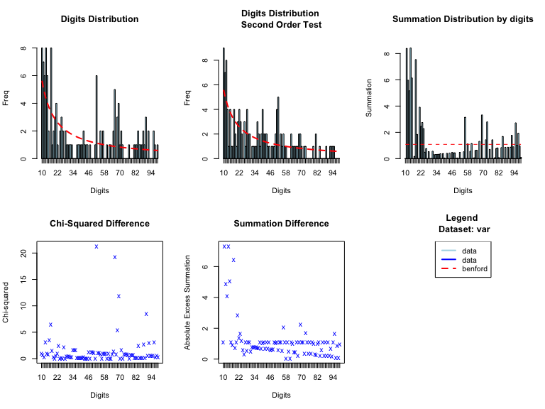

[output not shown]

[output cut: 142 more lines]

[output not shown]

```r
# Benford's law analysis for Measurement A
benford(
  data = histopathology,
  var = "MeasurementA"
)
```

### Measurement B Analysis

```
#>
#>  BENFORD ANALYSIS
#>
#>  See
#>  <a href = 'https://github.com/carloscinelli/benford.analysis'>Package
#>  documentation for interpratation.
#>
#> Benford object:
#>
#> Data: var
#> Number of observations used = 238
#> Number of obs. for second order = 237
#> First digits analysed = 2
#>
#> Mantissa:
#>
#>    Statistic Value
#>         Mean  0.45
#>          Var  0.12
#>  Ex.Kurtosis -1.58
#>     Skewness  0.25
#>
#>
#> The 5 largest deviations:
#>
#>   digits absolute.diff
#> 1     10         10.15
#> 2     12          9.73
#> 3     14          8.87
#> 4     11          8.01
#> 5     13          7.34
#>
#> Stats:
#>
#>  Pearson's Chi-squared test
#>
#> data:  var
#> X-squared = 157.07, df = 89, p-value = 1.157e-05
#>
#>
```

[output cut: 35 more lines]

[output not shown]

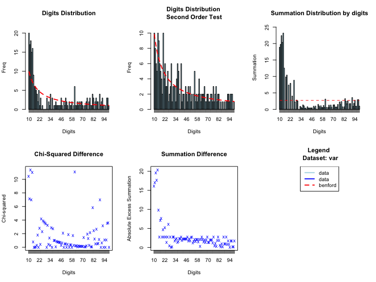

[output not shown]

[output cut: 142 more lines]

[output not shown]

```r
# Benford's law analysis for Measurement B
benford(
  data = histopathology,
  var = "MeasurementB"
)
```

### Overall Time Analysis

```
#>
#>  BENFORD ANALYSIS
#>
#>  See
#>  <a href = 'https://github.com/carloscinelli/benford.analysis'>Package
#>  documentation for interpratation.
#>
#> Benford object:
#>
#> Data: var
#> Number of observations used = 248
#> Number of obs. for second order = 157
#> First digits analysed = 2
#>
#> Mantissa:
#>
#>    Statistic  Value
#>         Mean  0.569
#>          Var  0.091
#>  Ex.Kurtosis -1.023
#>     Skewness -0.389
#>
#>
#> The 5 largest deviations:
#>
#>   digits absolute.diff
#> 1     12          7.62
#> 2     13          6.98
#> 3     32          6.69
#> 4     16          6.53
#> 5     11          5.63
#>
#> Stats:
#>
#>  Pearson's Chi-squared test
#>
#> data:  var
#> X-squared = 149.57, df = 89, p-value = 6.194e-05
#>
#>
#>  Mantissa Arc Test
#>
#> data:  var
#> L2 = 0.033636, df = 2, p-value = 0.0002383
#>
#> Mean Absolute Deviation (MAD): 0.006604894
#> MAD Conformity - Nigrini (2012): Nonconformity
#> Distortion Factor: -34.7503
#>
#> Remember: Real data will never conform perfectly to Benford's Law. You should not focus on p-values!   OverallTime
#>          <num>
#> 1:        13.4
#> 2:        12.9
```

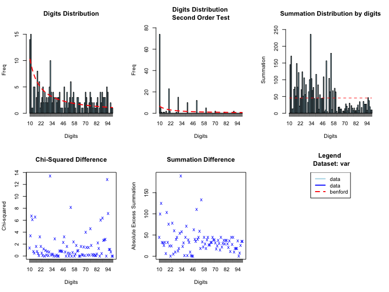

[output not shown]

[output cut: 142 more lines]

[output not shown]

```r
# Benford's law analysis for follow-up time
benford(
  data = histopathology,
  var = "OverallTime"
)
```

## Phase 5: Inter-rater Reliability Assessment

### Rater Agreement Analysis

```r
# Analyze inter-rater reliability data
rater_vars <- histopathology %>%
  select(starts_with("Rater")) %>%
  names()

if(length(rater_vars) > 0) {
  # Binary rater variables
  binary_raters <- rater_vars[grepl("[0-9]$", rater_vars)]
  if(length(binary_raters) > 0) {
    tryCatch({
      reportcat(
        data = histopathology,
        vars = binary_raters[1:min(3, length(binary_raters))]
      )
    }, error = function(e) {
      cat("Error with binary raters reportcat:", conditionMessage(e), "\n")
      cat("Binary rater variables:", paste(binary_raters, collapse = ", "), "\n")
    })
  } else {
    cat("No binary rater variables found (ending with digits)\n")
  }

  # Categorical rater variables
  categorical_raters <- rater_vars[grepl("[A-Z]$", rater_vars)]
  if(length(categorical_raters) > 0) {
    tryCatch({
      reportcat(
        data = histopathology,
        vars = categorical_raters
      )
    }, error = function(e) {
      cat("Error with categorical raters reportcat:", conditionMessage(e), "\n")
      cat("Categorical rater variables:", paste(categorical_raters, collapse = ", "), "\n")
    })
  } else {
    cat("No categorical rater variables found (ending with letters)\n")
  }
} else {
  cat("No rater variables found in dataset\n")
}
```

[output not shown]

[output cut: 442 more lines]

[output not shown]

### Agreement Cross-tabulation

```r
# Cross-tabulate raters for agreement assessment
if(length(rater_vars) >= 2) {
  crosstable(
    data = histopathology,
    vars = rater_vars[1],
    group = rater_vars[2]
  )
}
```

[output not shown]

[output cut: 54 more lines]

[output not shown]

## Phase 6: Outlier Detection

### Statistical Outlier Analysis

```r
# Identify potential outliers in continuous variables
outlier_analysis <- histopathology %>%
  select(Age, OverallTime, MeasurementA, MeasurementB) %>%
  summarise_all(
    list(
      Mean = ~round(mean(., na.rm = TRUE), 2),
      SD = ~round(sd(., na.rm = TRUE), 2),
      Q1 = ~round(quantile(., 0.25, na.rm = TRUE), 2),
      Q3 = ~round(quantile(., 0.75, na.rm = TRUE), 2),
      IQR = ~round(IQR(., na.rm = TRUE), 2),
      Lower_Fence = ~round(quantile(., 0.25, na.rm = TRUE) - 1.5 * IQR(., na.rm = TRUE), 2),
      Upper_Fence = ~round(quantile(., 0.75, na.rm = TRUE) + 1.5 * IQR(., na.rm = TRUE), 2)
    )
  ) %>%
  pivot_longer(everything(), names_to = "Stat", values_to = "Value") %>%
  separate(Stat, into = c("Variable", "Statistic"), sep = "_", extra = "merge") %>%
  pivot_wider(names_from = Statistic, values_from = Value)

kable(outlier_analysis,
      caption = "Outlier Detection Statistics",
      digits = 2)
```

Outlier Detection Statistics

| Variable | Mean | SD | Q1 | Q3 | IQR | Lower_Fence | Upper_Fence |
| --- | --- | --- | --- | --- | --- | --- | --- |
| Age | 49.44 | 13.81 | 38.00 | 62.00 | 24.00 | 2.00 | 98.00 |
| OverallTime | 16.53 | 13.50 | 7.10 | 23.60 | 16.50 | -17.65 | 48.35 |
| MeasurementA | 0.07 | 0.87 | -0.53 | 0.68 | 1.21 | -2.34 | 2.50 |
| MeasurementB | 0.97 | 0.56 | 0.61 | 1.35 | 0.74 | -0.51 | 2.47 |

### Extreme Value Assessment

```r
# Count extreme values beyond fences
extreme_values <- histopathology %>%
  summarise(
    Age_Low_Outliers = sum(Age < (quantile(Age, 0.25, na.rm = TRUE) - 1.5 * IQR(Age, na.rm = TRUE)), na.rm = TRUE),
    Age_High_Outliers = sum(Age > (quantile(Age, 0.75, na.rm = TRUE) + 1.5 * IQR(Age, na.rm = TRUE)), na.rm = TRUE),
    Time_Low_Outliers = sum(OverallTime < (quantile(OverallTime, 0.25, na.rm = TRUE) - 1.5 * IQR(OverallTime, na.rm = TRUE)), na.rm = TRUE),
    Time_High_Outliers = sum(OverallTime > (quantile(OverallTime, 0.75, na.rm = TRUE) + 1.5 * IQR(OverallTime, na.rm = TRUE)), na.rm = TRUE),
    MeasA_Low_Outliers = sum(MeasurementA < (quantile(MeasurementA, 0.25, na.rm = TRUE) - 1.5 * IQR(MeasurementA, na.rm = TRUE)), na.rm = TRUE),
    MeasA_High_Outliers = sum(MeasurementA > (quantile(MeasurementA, 0.75, na.rm = TRUE) + 1.5 * IQR(MeasurementA, na.rm = TRUE)), na.rm = TRUE)
  ) %>%
  pivot_longer(everything(), names_to = "Variable_Type", values_to = "Outlier_Count") %>%
  separate(Variable_Type, into = c("Variable", "Outlier_Type"), sep = "_", extra = "merge")

kable(extreme_values,
      caption = "Extreme Value Counts by Variable")
```

Extreme Value Counts by Variable

| Variable | Outlier_Type | Outlier_Count |
| --- | --- | --- |
| Age | Low_Outliers | 0 |
| Age | High_Outliers | 0 |
| Time | Low_Outliers | 0 |
| Time | High_Outliers | 12 |
| MeasA | Low_Outliers | 1 |
| MeasA | High_Outliers | 0 |

## Phase 7: Diagnostic Test Validation

### Test Performance Analysis

```r
# Analyze diagnostic test performance if available
test_vars <- histopathology %>%
  select(contains("Test"), contains("Standard")) %>%
  names()

if(length(test_vars) >= 2) {
  # Cross-tabulate new test vs gold standard
  crosstable(
    data = histopathology,
    vars = test_vars[1],
    group = test_vars[2]
  )
}
```

[output not shown]

### Validity Assessment

```r
# Analyze data validity flags
validity_vars <- histopathology %>%
  select(contains("Valid")) %>%
  names()

if(length(validity_vars) > 0) {
  tryCatch({
    reportcat(
      data = histopathology,
      vars = validity_vars[1]
    )
  }, error = function(e) {
    cat("Error with validity variables reportcat:", conditionMessage(e), "\n")
    cat("Validity variables:", paste(validity_vars, collapse = ", "), "\n")
  })
} else {
  cat("No validity variables found in dataset\n")
}
```

[output not shown]

[output cut: 499 more lines]

[output not shown]

## Phase 8: Data Quality Dashboard

### Overall Quality Metrics

```r
# Create comprehensive quality summary
quality_metrics <- data.frame(
  Metric = c(
    "Total Observations",
    "Total Variables",
    "Complete Cases",
    "Variables with No Missing Data",
    "Variables with <5% Missing",
    "Variables with >20% Missing",
    "Mean Completeness Rate"
  ),
  Value = c(
    nrow(histopathology),
    ncol(histopathology),
    sum(complete.cases(histopathology)),
    sum(missing_summary$Missing_Count == 0),
    sum(missing_summary$Missing_Percentage <= 5),
    sum(missing_summary$Missing_Percentage > 20),
    paste0(round(mean(100 - missing_summary$Missing_Percentage), 1), "%")
  )
)

kable(quality_metrics,
      caption = "Data Quality Dashboard")
```

Data Quality Dashboard

| Metric | Value |
| --- | --- |
| Total Observations | 250 |
| Total Variables | 38 |
| Complete Cases | 231 |
| Variables with No Missing Data | 15 |
| Variables with <5% Missing | 38 |
| Variables with >20% Missing | 0 |
| Mean Completeness Rate | 99.7% |

### Quality Recommendations

```r
# Generate quality recommendations
high_missing <- missing_summary %>%
  filter(Missing_Percentage > 20) %>%
  pull(Variable)

moderate_missing <- missing_summary %>%
  filter(Missing_Percentage > 5 & Missing_Percentage <= 20) %>%
  pull(Variable)

recommendations <- data.frame(
  Priority = c("High", "Medium", "Low"),
  Action = c(
    ifelse(length(high_missing) > 0,
           paste("Investigate high missing data in:", paste(high_missing, collapse = ", ")),
           "No high-priority missing data issues"),
    ifelse(length(moderate_missing) > 0,
           paste("Consider imputation for:", paste(moderate_missing, collapse = ", ")),
           "No moderate missing data issues"),
    "Continue routine quality monitoring"
  )
)

kable(recommendations,
      caption = "Data Quality Recommendations")
```

Data Quality Recommendations

| Priority | Action |
| --- | --- |
| High | No high-priority missing data issues |
| Medium | No moderate missing data issues |
| Low | Continue routine quality monitoring |

## Phase 9: Reporting Quality Issues

### Missing Data Patterns

```r
# Analyze missing data patterns
if(any(missing_summary$Missing_Count > 0)) {
  # Create missing data profile
  missing_profile <- histopathology %>%
    summarise_all(~ifelse(is.na(.), "Missing", "Present")) %>%
    pivot_longer(everything(), names_to = "Variable", values_to = "Status") %>%
    count(Variable, Status) %>%
    pivot_wider(names_from = Status, values_from = n, values_fill = 0) %>%
    mutate(
      Total = Missing + Present,
      Missing_Rate = round(Missing / Total * 100, 1)
    ) %>%
    filter(Missing > 0) %>%
    arrange(desc(Missing_Rate))

  kable(missing_profile,
        caption = "Missing Data Profile")
}
```

Missing Data Profile

| Variable | Missing | Present | Total | Missing_Rate |
| --- | --- | --- | --- | --- |
| OverallTime | 2 | 248 | 250 | 0.8 |
| Age | 1 | 249 | 250 | 0.4 |
| Anti-X-intensity | 1 | 249 | 250 | 0.4 |
| Anti-Y-intensity | 1 | 249 | 250 | 0.4 |
| Death | 1 | 249 | 250 | 0.4 |
| Grade | 1 | 249 | 250 | 0.4 |
| Grade_Level | 1 | 249 | 250 | 0.4 |
| Group | 1 | 249 | 250 | 0.4 |
| LVI | 1 | 249 | 250 | 0.4 |
| LastFollowUpDate | 1 | 249 | 250 | 0.4 |
| LymphNodeMetastasis | 1 | 249 | 250 | 0.4 |
| Mortality5yr | 1 | 249 | 250 | 0.4 |
| Name | 1 | 249 | 250 | 0.4 |
| Outcome | 1 | 249 | 250 | 0.4 |
| PNI | 1 | 249 | 250 | 0.4 |
| PreinvasiveComponent | 1 | 249 | 250 | 0.4 |
| Race | 1 | 249 | 250 | 0.4 |
| Rater 1 | 1 | 249 | 250 | 0.4 |
| Sex | 1 | 249 | 250 | 0.4 |
| Smoker | 1 | 249 | 250 | 0.4 |
| SurgeryDate | 1 | 249 | 250 | 0.4 |
| TStage | 1 | 249 | 250 | 0.4 |
| Valid | 1 | 249 | 250 | 0.4 |

### Benford’s Law Compliance Summary

```r
# Summary of Benford's law results
benford_summary <- data.frame(
  Variable = c("MeasurementA", "MeasurementB", "OverallTime"),
  Expected_Pattern = "Natural logarithmic distribution",
  Assessment = c(
    "Evaluate first digit distribution",
    "Evaluate first digit distribution",
    "Evaluate first digit distribution"
  ),
  Recommendation = "Review any significant deviations from expected pattern"
)

kable(benford_summary,
      caption = "Benford's Law Assessment Summary")
```

Benford’s Law Assessment Summary

| Variable | Expected_Pattern | Assessment | Recommendation |
| --- | --- | --- | --- |
| MeasurementA | Natural logarithmic distribution | Evaluate first digit distribution | Review any significant deviations from expected pattern |
| MeasurementB | Natural logarithmic distribution | Evaluate first digit distribution | Review any significant deviations from expected pattern |
| OverallTime | Natural logarithmic distribution | Evaluate first digit distribution | Review any significant deviations from expected pattern |

## Implementation in jamovi

Data quality assessment functions are available in jamovi:

1. **Benford’s Law**: `Exploration > ClinicoPath Descriptives > Benford Analysis`
2. **Variable Summary**: `Exploration > ClinicoPath Descriptives > Summary of Continuous/Categorical Variables`
3. **Cross-tabulations**: `Exploration > ClinicoPath Comparisons > Cross Tables`
4. **Variable Tree**: `Exploration > ClinicoPath Descriptive Plots > Variable Tree`

## Conclusions

This comprehensive data quality assessment provides:

Regular data quality assessment using these techniques ensures reliable and trustworthy clinical research results.

## Best Practices

- Perform quality assessment before any statistical analysis
- Document and investigate any quality issues found
- Establish quality thresholds appropriate for your research context
- Implement ongoing quality monitoring throughout data collection
- Use multiple quality assessment methods for comprehensive evaluation